# 6_1_BenchmarkModels_FittedValues_Forecasts

# References

1. Hyndman, R.J., & Athanasopoulos, G., 2021. *Forecasting: principles and practice*. 3rd edition.
2. Fable package documentation
- https://fable.tidyverts.org/index.html
- https://fable.tidyverts.org/articles/fable.html

# Libraries

```r
library(fpp3)
```

# Introduction

In this session we are going to:

- Introduce the concept of fitted values.
- Explore some **benchmark models**. These are models that are simple in nature, but yet will serve as a measure of performance to which we will compare more complex models.
  - If more complex models do not outperform this benchmark models, their complexity will not be justified.
- Practice the basic steps behind fitting models and forecasting with the library `fable`.
- Introduce the concept of fitted values and compare it to forecasts.
- Do some exercises.

For the most of the simple examples in this notebook we will work with this time series studying the production of bricks between 1970 and 2004:

```r
bricks <- aus_production %>%
  filter_index("1970 Q1" ~ "2004 Q4") %>%
  select(Bricks)

head(bricks)
```

```
# A tsibble: 6 x 2 [1Q]
  Bricks Quarter
   <dbl>   <qtr>
1    386 1970 Q1
2    428 1970 Q2
3    434 1970 Q3
4    417 1970 Q4
5    385 1971 Q1
6    433 1971 Q2
```

# Fitted values vs forecasts

Before using a model, we will need to **fit that model** (classic math terminology) also known as **training the model** (machine learning terminology). This means that we will **use data to produce estimates of the parameters of the model**. We will call this data **training data**.

Note **a few important technical details**:

- I talk about **estimates of the parameters** because **we are estimating these parameters from a particular sample** or in our case, **from a particular realisation of the time series**.
  - **Notation:** $\beta$ would be a parameter, while $\hat{\beta}$ would be the estimate of that parameter.
  - Many times we will abuse this notation and write $\beta$ instead of $\hat{\beta}$, but know that, when fitting a model, we are producing estimates of the parameters.
- If we fitted the model to another sample or to another realization of the time series (think of this as repeating an experiment), we would produce different estimates of those parameters.
- Being estimates, those parameters have associated standard errors.

## Fitted values - example with linear regression

Now **let us resort to your knowledge of linear regression to ilustrate the concept of fitted values**. When fitting a linear regression model to predict a variable $y$ based on the values of a predictor $x$, we take a sample of data (our training data) and produce estimates of the model parameters.

Once these parameters have been produced, we can compute the values of $y$ predicted by the model for the ranges of values of $x$ to which the training data belongs. **These predictions would be the fitted values of the linear regression model**. The image below illustrates this:

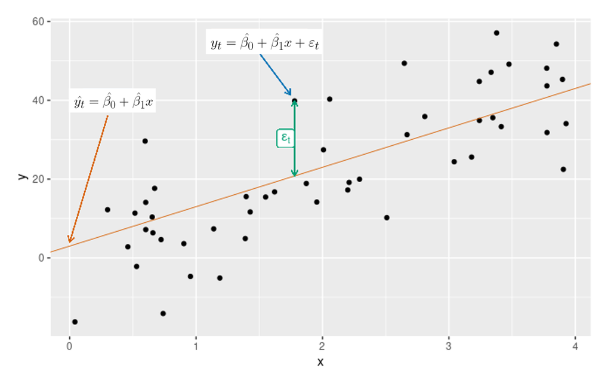

## Fitted values - time series case.

When **fitting a time series model to a given realization of a time series** - that is, to our **training data** - the goal is to **produce estimates of the model parameters**.

Fitted values are almost always **one-step in-sample (i.e., in the time region of the training data) “forecasts”**.

- **one-step ahead** means that the forecast only extend one time step into the future.
- **in-sample** means that the forecasts belong to the time-region of the training data.
- **To prodouce the one-step ahead forecast at time $t$**, only information up to $t-1$ is considered. We will see that this is technically not always the case for all fitted values.

We denote the fitted value at time $t$ as $\hat{y}_{t|t-1}$, meaning the forecast of $y_t$ based on observations $y_{1},\dots,y_{t-1}$. **We will abuse notation and sometimes refer to the fitted values them simply as** $\hat{y_t}$ instead of $\hat{y}_{t|t-1}$.

The graph below illustrates this (it is an example using the Naïve model, which we will see later in this notebook). The black line represents the `bricks` time series and the dashed blue line represents the fitted values:

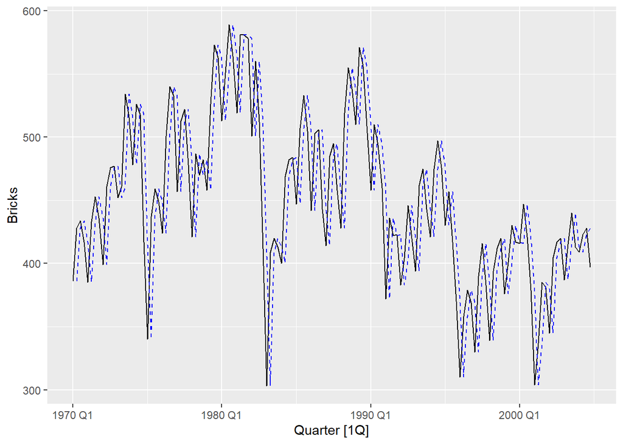

**In most instances fitted values will be one-step ahead forecasts, but in some instances (for example the MEAN mode), they wont**.

## Forecasts compared to fitted values

Unlike fitted valued, forecasts extend **beyond the range of time of the training data** and can be **multi-step**, meaning they can extend various time-steps into the future. The example below illustrates this difference for the Naive method and the bricks dataset. We will explain the Naive method later in the notebook. For the time being focus on understanding this difference:

- Forecasts are depicted in a continuous blue line.
- Fitted values are depicted as a blue-dashed line.
- The original time series, which has been used in its entirety as training data, is depicted in black.

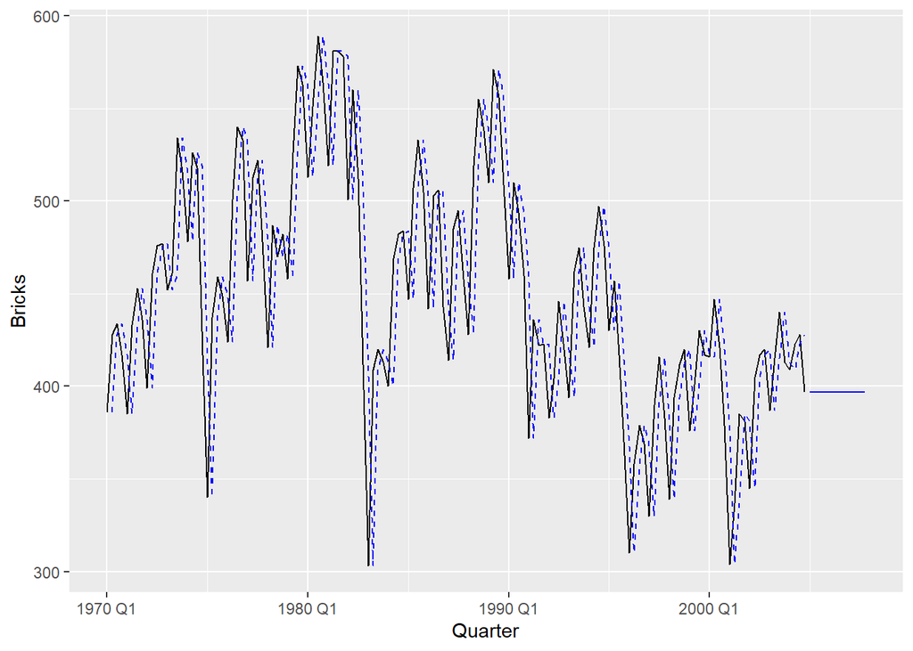